# Praca domowa 2

Przemysław Chojecki

22 03 2020

## Kodowanie zmiennych kategorycznych

Jeśli mamy do czynienia ze zmiennymi kategorycznymi w czasie uczenia maszynowego musimy te zmienne w jakis sposób zakodować.  
* `target encoding` polega na tym, że w ramach każdej z kategorii liczymy średnią z kolumny `target` i wpisujemy ją zamiast zmiennej kategorycznej.  
* `one-hot encoding` polega na tym, że każdą z kategorii zamieniamy na nową kolumnę z zerami, jeśli rekord nie jest w danej kategorii oraz jedynkami, jeśli jest.

### Przyklad

```r
A <- read.csv("allegro-api-transactions.csv")
data <- A

# pozbedziemy sie powtorek
data$it_location %>% table %>% length # 10_056
```

```
## [1] 10056
```

```r
data$it_location %>% str_to_upper() %>% table %>% length # 7_903
```

```
## [1] 7903
```

```r
data$it_location <- data$it_location %>% str_to_upper()
```

#### `target encoding`

```r
srednie <- data %>% group_by(it_location) %>% summarise(avr_price = mean(price))
data <- data %>% left_join(srednie, by = c("it_location" = "it_location")) %>% select(-it_location, it_location_avr_price = avr_price)
```

Ile jest rekordow o okreslonej wielkosci parametru `it_location_avr_price`?

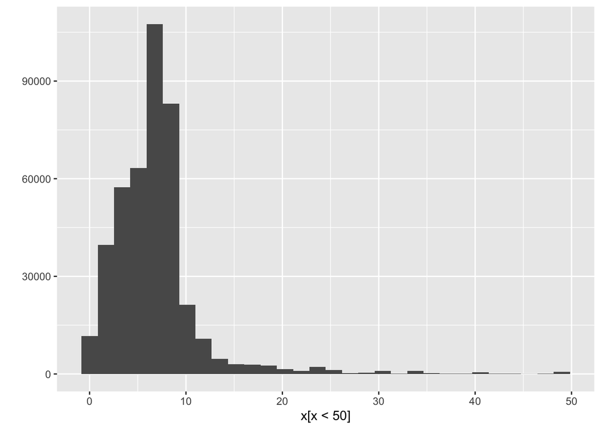

```r
x <- (data$it_location_avr_price/10) %>% floor()
qplot(x[x<50], geom="histogram")
```

#### `one-hot encodeing`

```r
B <- data %>% select(price, main_category) %>% createDummyFeatures(target = "price", method = "1-of-n")
data_1_of_n <- data %>% select(-main_category) %>% cbind(B)
data_1_of_n %>% colnames() %>% length() # jest 41 kolumn
```

```
## [1] 41
```

```r
B <- data %>% select(price, main_category) %>% createDummyFeatures(target = "price", method = "reference")
data_reference <- data %>% select(-main_category) %>% cbind(B)
data_reference %>% colnames() %>% length() # jest 40 kolumn, o jedna mniej, gdyz jest zbedna
```

```
## [1] 40
```

W metodzie `reference` efekt końcowy ma jedna kolumnę mniej, gdyż jest to kolumna, ktora ma jedynki dokladnie tam, gdzie wszystkie pozostale nowoutworzone mają zera.

### Zady i walety

Oba rozwiązania mają swoje plusy i minusy. Jeśli zastosujemy `target encoding` nie zwiękrzymy wolumenu danych, gdyż jedną kolumnę zastępujemy inną. Odwrotnie w `one-hot encodeing`, gdzie tworzymy tyle nowych kolumn, ile jest różnych wartości `factor`a, dlatego nie mogliśmy urzyć tej metody w pierwszym przypadku, gdyrz powstałyby $7903$ kolumny, co jest niedopuszczalne przy uczeniu, obliczenia niesamowicie by się wydłużyły.  
Problemem natomiast `target encoding`u jest, że bardzo łatwo jest wpaść w `over-fitting`. Wystarczy, że mamy wartość faktora występującą dokładnie raz i zamieniamy ją na dokładną wartość `target`u, co może być problematyczne przy uczeniu.

## Uzupelnianie braków

Zmniejszenie wolumenu danych:

```r
m <- (A %>% dim)[1]
wybor <- sample(m, floor(m/10))
data <- (A %>% select(price, it_seller_rating, it_quantity))[wybor,]
```

### `it_seller_rating`

Obliczenie $10$cio krotne:

```r
odchylenie_standardowe_x <- numeric(10)
odchylenie_standardowe_x_missing <- numeric(10)

for(i in 1:10){
  m <- (data %>% dim)[1]

  data_NA_seller_rating <- data
  missing <- sample(m, floor(m/10))
  data_NA_seller_rating$it_seller_rating[missing] <- NA

  init <- mice(data_NA_seller_rating, maxit=0)
  meth <- init$method
  predM <- init$predictorMatrix

  quiet( imputed <- mice(data_NA_seller_rating, method=meth, predictorMatrix=predM, m=1) )

  imputed1 <- complete(imputed, action=1)

  x <- cbind(data %>% select(true = it_seller_rating), imputed1 %>% select(imputed = it_seller_rating))
  x_missing <- x[missing,]
  x %>% summary
  x_missing %>% summary

  odchylenie_standardowe_x[i] <- sqrt( ((x$true - x$imputed)^2 %>% sum)/(m) )
  odchylenie_standardowe_x_missing[i] <- sqrt( ((x_missing$true - x_missing$imputed)^2 %>% sum)/(m/10) )
}
```

Rysuneczek:

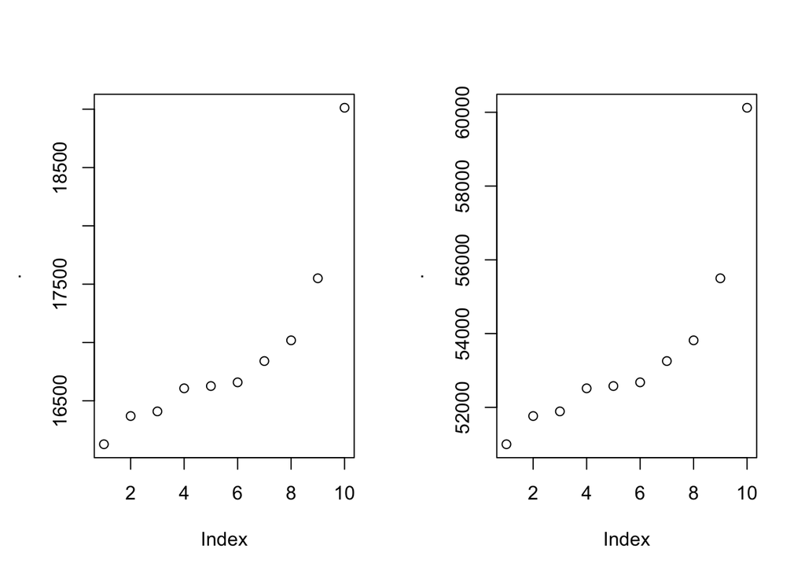

```r
par(mfrow = c(1,2))
odchylenie_standardowe_x %>% sort %>% plot
odchylenie_standardowe_x_missing %>% sort %>% plot
```

### `it_seller_rating` oraz `it_quantity`

Obliczenie $10$cio krotne:

```r
odchylenie_standardowe_x <- numeric(10)
odchylenie_standardowe_x_missing <- numeric(10)

for(i in 1:10){
  m <- (data %>% dim)[1]

  data_NA_quantity <- data
  missing <- sample(m, floor(m/10))
  data_NA_quantity$it_quantity[missing] <- NA

  missing <- sample(m, floor(m/10))
  data_NA_quantity$it_seller_rating[missing] <- NA

  init <- mice(data_NA_quantity, maxit=0)
  meth <- init$method
  predM <- init$predictorMatrix

  quiet( imputed <- mice(data_NA_quantity, method=meth, predictorMatrix=predM, m=1) )

  imputed1 <- complete(imputed, action=1)

  x <- cbind(data %>% select(true = it_seller_rating), imputed1 %>% select(imputed = it_seller_rating))
  x_missing <- x[missing,]
  x %>% summary
  x_missing %>% summary

  odchylenie_standardowe_x[i] <- sqrt( ((x$true - x$imputed)^2 %>% sum)/(m) )
  odchylenie_standardowe_x_missing[i] <- sqrt( ((x_missing$true - x_missing$imputed)^2 %>% sum)/(m/10) )
}
```

Rysuneczek:

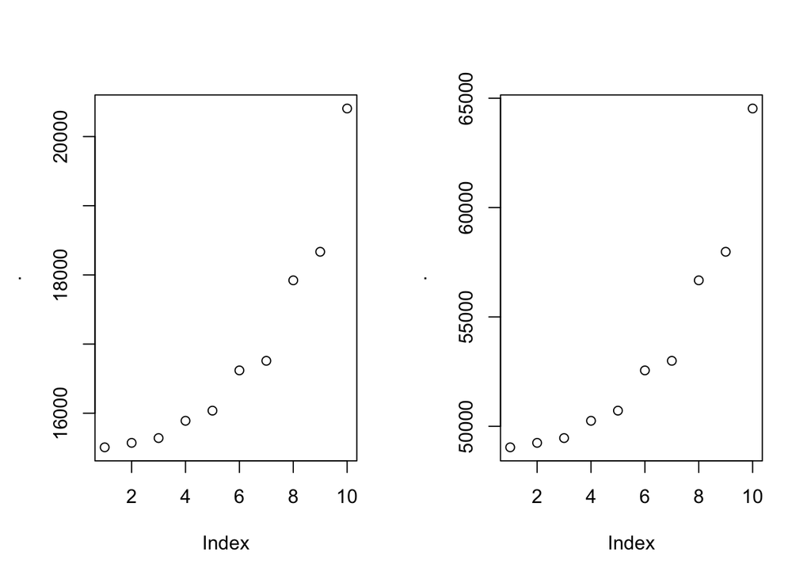

```r
par(mfrow = c(1,2))
odchylenie_standardowe_x %>% sort %>% plot
odchylenie_standardowe_x_missing %>% sort %>% plot
```